#### Prerequisites

The R **MODIS** package is a valuable set of functions to find, download and process level-3 products from the **Mod**erate Resolution **I**maging **S**pectroradiometer (MODIS) mounted aboard NASA’s Terra and Aqua satellite platforms. There is a comprehensive beginner’s guide on [Steven Mosher’s Blog](https://stevemosher.wordpress.com/modis-tutorial/) that describes how to successfully setup the **MODIS** package including all relevant prerequisites and which you might want to have a look at. Prerequisites include

- the [MODIS Reprojection Tool](https://lpdaac.usgs.gov/tools/modis_reprojection_tool) to automatically process the acquired MODIS data and
- [OSGeo4W](https://trac.osgeo.org/osgeo4w/) featuring all required GDAL libraries.

Once installed, the **MODIS** package will automatically check if all required software packages are installed on your local machine and make suggestions in case any of the two is missing.

#### Installing the **MODIS** package

Since it is not (yet) an official CRAN package, **MODIS** is currently hosted on [R-Forge](https://r-forge.r-project.org/R/?group_id=1252). The latest package version 0.10-33 can easily be installed using

```r
## package url
modis_url <- "http://download.r-forge.r-project.org/src/contrib/MODIS_0.10-33.tar.gz"

## install package
install.packages(modis_url, repos = NULL)
```

#### Checking the **MODIS** installation

Before anything else, make sure all additionally required packages (the so-called ‘dependencies’) are installed via

```r
MODIS:::checkDeps()
```

```
## All suggested packages are installed
```

If this operation fails, you will automatically be prompted to install whatever packages are missing in order to solve this issue. Next, you should tell **MODIS** where to store downloaded (`localArcPath`) and processed (`outDirPath`) MODIS imagery. For the moment, let us save all downloaded data in a subfolder of our current working directory named ‘data’ and all processed data in a subfolder named ‘data/processed’.

```r
## load required package without startup messages
library(MODIS)

## set output folders (messages disabled)
MODISoptions(localArcPath = "data/",
             outDirPath = "data/processed/",
             quiet = TRUE)
```

There is also a function to check whether all of the above-mentioned external software tools are installed and their system paths are set properly (Windows sends its regards…).

```r
MODIS:::checkTools()
```

```
## Checking availabillity of MRT:
##   'MRT_HOME' found: /home/fdetsch/apps/mrt
##   'MRT_DATA_DIR' found: /home/fdetsch/apps/mrt/data
##    MRT enabled, settings are fine!
## Checking availabillity of GDAL:
##    OK, GDAL 1.11.1, released 2014/09/24 found!
```

If no further warnings occurred, then you are now ready to start. Well, almost…

#### Sinusoidal tile grid

Before launching a download, be advised that high-order MODIS products are commonly subdivided into tiles based on the so-called [Sinusoidal tile grid](http://modis-land.gsfc.nasa.gov/MODLAND_grid.html) (see image below). Make sure to identify the coordinates (in **h**orizontal and **v**ertical direction) of the tile you would like to process before commencing with the actual data download - it will save you a lot of time!

[figure not shown]

#### Data download

Right now, the package offers support for MODIS land products (distributed via [LPDAAC](https://lpdaac.usgs.gov/) and [LAADS](https://ladsweb.nascom.nasa.gov/) only. For a full list of available datasets, type `getProduct()`. For the moment, let us download some 1-km resolution 16-day Terra-MODIS NDVI images (product ‘MOD13A2’) from August 2015 over Cape Verde. You may possibly have noticed alreaedy from the image above that Cape Verde is included in tile h15v07. Here is a list of arguments you will need in the following. For more detailed information, have a look at `?getHdf`.

- `product`: MODIS product to be downloaded
- `begin`: start date (“YYYY-MM-DD”)
- `end`: end date (“YYYY-MM-DD”)
- `tileH`: **h**orizontal coordinate of the desired MODIS tile
- `tileV`: **v**ertical coordinate of the desired MODIS tile

Alright, let us give it a try. Remember that an entire MODIS tile will be downloaded, so this might take a few seconds.

```r
## download data
getHdf(product = "MOD13A2",
       begin = "2015-08-01", end = "2015-08-14",
       tileH = 15, tileV = 7)
```

#### (Download and) process data

Unfortunatelly, MODIS data commonly come in .hdf format that most users are rather unfamiliar with. Luckily, **MODIS** provides functionality to automatically extract ordinary GeoTiff (.tif) images from the .hdf container file. The referring function is called `runGdal` and works very similar to the previous `getHdf` command. A quick look at `?runGdal` reveals that this function supports even more specifiable arguments. Amongst those are

- `SDSstring`: the desired scientific datasets (SDS) to extract; see e.g. [the MOD13A2 product description](https://lpdaac.usgs.gov/dataset_discovery/modis/modis_products_table/mod13a2) (tab ‘Layers’) for a detailed list of SDS that come with the product
- `outProj`: the desired output projection
- `job`: a job name which will be passed on to the subfolder in ‘processed’

We will set `SDSstring = "10000000000` since, for the moment, we are only interested in the raw NDVI values. Furthermore, we will specify ordinary ‘Latlong’ (EPSG:4326) as output projection. Note that if you are willing to download and extract MODIS data in one step, you may simply use `runGdal` instead of `getHdf`. Alright, let’s try this.

```r
runGdal(product = "MOD13A2",
        begin = "2015-08-01", end = "2015-08-14",
        tileH = 15, tileV = 7,
        SDSstring = "10000000000",
        outProj = "4326",
        job = "ndvi_1km_16day",
        quiet = TRUE)
```

```
## ########################
## outProj          =  +init=epsg:4326 +proj=longlat +datum=WGS84 +no_defs +ellps=WGS84 +towgs84=0,0,0
## pixelSize        =  asIn
## resamplingType   =  near
## Output Directory =  /mnt/windows/Permanent/xchange/thomas/data/processed/ndvi_1km_16day
## ########################
```

#### Wrap-up

If everything worked out fine, there should now be a file named ‘ndvi_1km_16day/MOD13A2.A2015225.1_km_16_days_NDVI.tif’ in the ‘data/processed’ subfolder. You may want to have a look at it using

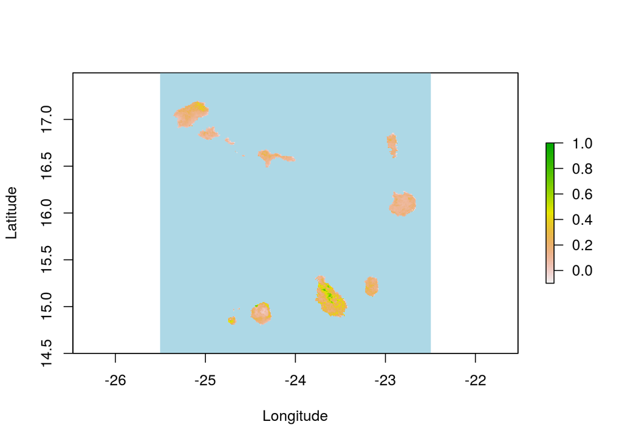

```r
## import raster file
rst <- raster("data/processed/ndvi_1km_16day/MOD13A2.A2015225.1_km_16_days_NDVI.tif")

## visualize ndvi image (multiplied by scale factor)
plot(rst * 0.0001, xlim = c(-25.5, -22.5), ylim = c(14.5, 17.5),
     zlim = c(-0.1, 1), colNA = "lightblue",
     xlab = "Longitude", ylab = "Latitude")
```